# Lab_08T

36-290 – Statistical Research Methodology

Week 8 Tuesday – Fall 2021

# Preliminaries

## Goal

Today you will largely follow the script of the last lab, while applying random forest in place of classification and regression trees.

# Data, Part I

Below we read in the same data that we used last time, except that we downsample the data to have sizes 10000 (train) and 5000 (test) to keep computation time manageable. (Random forest takes time because you generate 500 trees by default.)

```r
file.path = "https://raw.githubusercontent.com/pefreeman/36-290/master/EXAMPLE_DATASETS/DM_GALAXY/Massive_Black_II.Rdata"
load(url(file.path))
rm(file.path)

resp.train = resp.train.df$prop.sfr
w = which(resp.train>0)
pred.train = pred.train[w,]
resp.train = log10(resp.train[w])

resp.test  = resp.test.df$prop.sfr
w = which(resp.test>0)
pred.test = pred.test[w,]
resp.test = log10(resp.test[w])

set.seed(202)
s = sample(length(resp.train),10000)
pred.train = pred.train[s,]
resp.train = resp.train[s]
s = sample(length(resp.test),5000)
pred.test = pred.test[s,]
resp.test = resp.test[s]

cat("Sample sizes: train = ",length(resp.train)," test = ",length(resp.test),"\n")
```

```
## Sample sizes: train =  10000  test =  5000
```

# Questions

## Question 1

Because we reduced the sample size relative to that in the last lab, re-determine the test-set MSE for a linear regression model and then determine the test-set MSE for a random forest model. (In the argument list for `randomForest`, set `importance=TRUE`) Also display the predicted response versus observed response diagnostic plot (with the same limits on each axis!). Did the test-set MSE improve by using random forest? **Note: for reproducible results, set the seed before running random forest!**

```r
model = lm(resp.train~.,data=pred.train)
model
```

```
##
## Call:
## lm(formula = resp.train ~ ., data = pred.train)
##
## Coefficients:
##  (Intercept)   halos.vdisp   halos.vcirc   halos.rcirc    halos.m_dm
##    -6.850844      0.373528      2.807994     -0.129506     -0.030723
##     r_parent  shapesDM.q3d  shapesDM.s3d      thetaTid        phiTid
##     0.093080     -0.504993     -0.133135      0.001915     -0.002058
```

```r
resp.pred.lm = predict(model,newdata=pred.test)

lmtest_MSE = mean((resp.test - resp.pred.lm) ^ 2)
lmtest_MSE
```

```
## [1] 0.2503715
```

```r
suppressMessages(library(tidyverse)) ; suppressMessages(library(randomForest))
set.seed(100)
rf.out = randomForest(resp.train~.,data=pred.train,importance=TRUE)
resp.pred.random = predict(rf.out,newdata=pred.test)

randomtest_MSE = mean((resp.test - resp.pred.random) ^ 2)
randomtest_MSE
```

```
## [1] 0.2317997
```

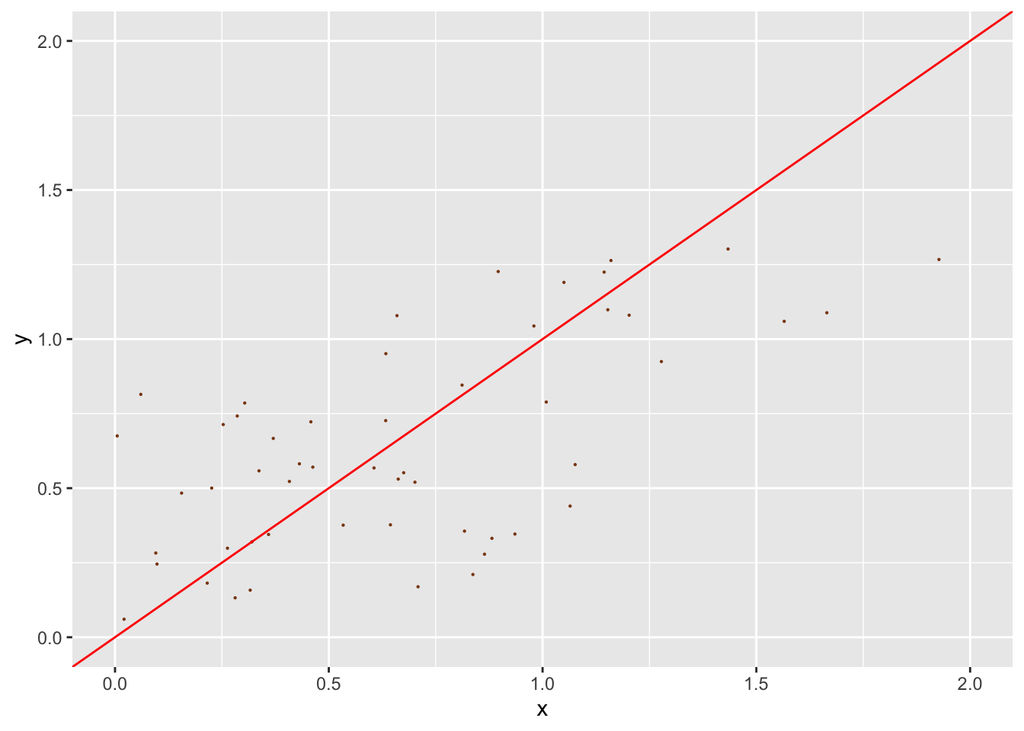

```r
ggplot(data=data.frame("x"=resp.test,"y"=resp.pred.random),mapping=aes(x=x,y=y)) +
  geom_point(size=0.1,color="saddlebrown") + xlim(0,2) + ylim(0,2) +
  geom_abline(intercept=0,slope=1,color="red")
```

```r
#what is predicted response versus observed response in this context?
```

```
lmtest_MSE: 0.2503715
randomtest_MSE:0.2317997
```

## Question 2

Create a variable importance plot for random forest. (See page 330 of ISLR.) You can subdivide the predictor variables into groups: those that reference dark matter particle velocity (ones with “v”), mass (“m”), or radius from the halo center (“r”), along with those that reference the gravitational potential (the ones with angle variables) and the shape of the halo (“shapes”). Do some inference: what is the most important property of a halo with regard to predicting star-formation rate? How about the least important?

```r
importance(rf.out)
```

```
##                %IncMSE IncNodePurity
## halos.vdisp  42.997170     1687.9787
## halos.vcirc  32.742505     1254.4667
## halos.rcirc  41.351133      517.8414
## halos.m_dm   37.116618      952.8701
## r_parent     33.806527      329.5572
## shapesDM.q3d 24.643819      241.6293
## shapesDM.s3d 19.603699      233.6918
## thetaTid      1.121380      220.5322
## phiTid       -1.061068      215.9240
```

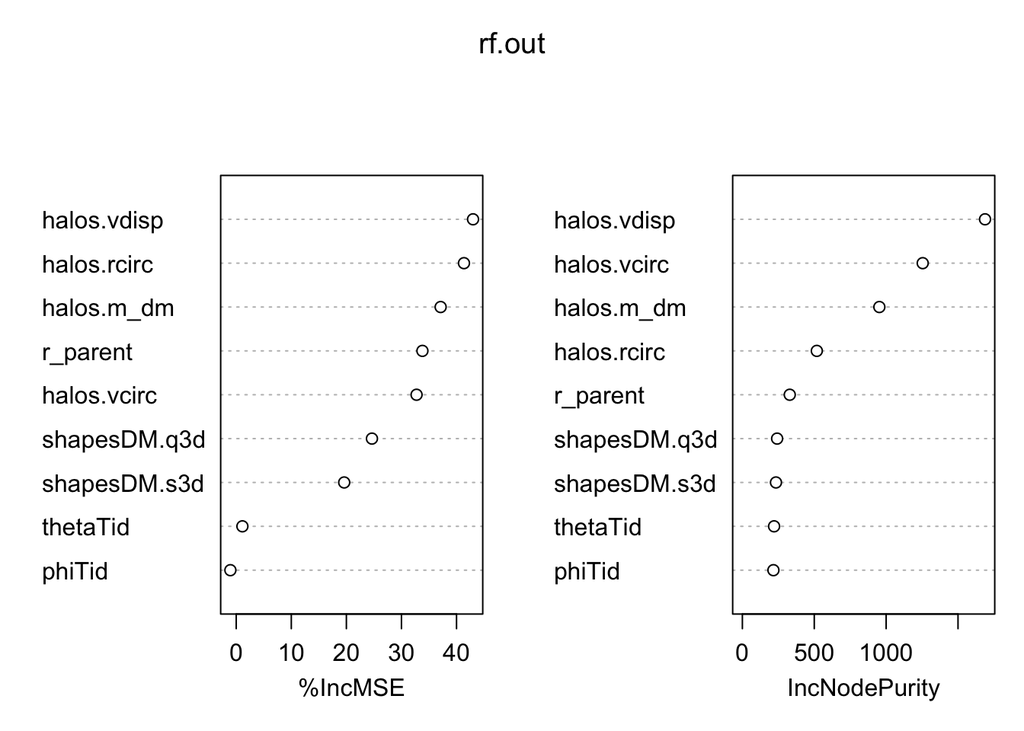

```
what is the most important property of a halo with regard to predicting star-formation rate?
-Halos.vdisp, halos.rcirc, halos.m_dm, r_parent, halos.vcirc

How about the least important?
-ShapesDM.q3d, shapesDM.s3d, thetaTid, phiTid
```

```r
varImpPlot(rf.out)
```

Now we turn our attention to classification.

# Data, Part II

We will now load the second dataset from the last lab, but we will do two things: (1) cut down the sample size to get random forest to run faster, and (2) balance the classes.

```r
rm(list=ls())

file.path = "https://raw.githubusercontent.com/pefreeman/36-290/master/EXAMPLE_DATASETS/TD_CLASS/css_data.Rdata"
load(url(file.path))
rm(file.path)

# Eliminate the max.slope column (the 11th column), which has infinities.
predictors = predictors[,-11]

# Cut the CB and NON-CB class sizes to 5000 samples each.
set.seed(303)
w = which(response==1)
s = sample(length(w),5000)
predictors.cb = predictors[w[s],]
response.cb   = response[w[s]]
w = which(response!=1)
s = sample(length(w),5000)
predictors.noncb = predictors[w[s],]
response.noncb   = response[w[s]]
predictors = rbind(predictors.cb,predictors.noncb)
response   = c(response.cb,response.noncb)

response.new = rep("CB",length(response))
w = which(response!=1)
response.new[w] = "NON-CB"
response = factor(response.new)
```